# EVDS Analysis

Ilgaz Gulsen - IE360 - Srping 2020

## 1.İntroduction

My research question is “İs total amount of debit and credit card expenditure related to consumer price index, unemployement rate and weighted average interest rates for banks loans?” The reason that I choose this topic is nowadays most of the time people use debit or credit cards instead of cashes. The idea behind this question is try to figure out which factors can affect percentage of credit or debit card usage. Without any analysis, first of all, I guess that people may be more likely to use cards when the unemployment rate increases. Because they need to maintain some basic needs. In addition, when the interest rate increases, people can decrease their habit of using cards. Maybe, they consider that usage of cards are not that much profitable at this point. Another guess is that people will increase their card usage due to the price index increase. Due to the price increases, they may not be able to pay cash to buy some products, so there might be a tendency to use cards.

## 2. Analysis Steps

Firstly, I decided of my data sets and dependent statistics. Each of my data set comes from different categories and their frequency is monthly. Then I downloaded these data sets from https://evds2.tcmb.gov.tr/ as an Excell file. After that I started to use Rstudio and I install the packages which I would have need in the analysis.

install.packages(“data.table”) library(data.table) install.packages(“xlsx”) install.packages(“zoo”) install.packages(“xts”) install.packages(“ggpubr”)

library(zoo) library(xts) library(readxl) library(ggpubr)

Then, read the Excel files by using the following codes.office online

data <- read_excel(“C:/Users/LENOVO/Desktop/EVDS.xlsx”) View(data)

The statistics that I had include 37 months of observations of my variables. So I created sequences of dates in order to obtain time series object. I created xts object that contains all data.

dates<- seq(from=as.Date(“2016-10-01”),to=as.Date(“2019-10-31”),by=“months”) genelxts<-xts(x=data[1:37,],order.by=dates)

The statistic that I wanted to interpret the relationsahip with other variables is Amount of credit and debit card expenditure. I created another time series object for this statistics.

card_exp <- data[1:37,2]  
cardxts<- xts(x=card_exp,order.by=dates) storage.mode(cardxts) <- “numeric” str(cardxts)

I wanted to see the relationships with Card expenditure with three variables. First of them is average interest for banks loans. I created xts object for this variable

loan_interest<- data[1:37,3]  
loanxts<- xts(x=loan_interest,order.by=dates) #xts object for interest rates of loans storage.mode(loanxts)<- “numeric”

The second variable is consumer price index. So I created another xts object for consumer price index.

price_index <- data[1:37,4]  
pricexts <- xts(x=price_index,order.by=dates) #xts object for price indexes storage.mode(pricexts)<- “numeric”

The third one is unemployemt rate. I created another xts object for it.

unemp_rate <-data[1:37,5] unempxts <- xts(x=unemp_rate,order.by=dates) #xts object for unemployement rates storage.mode(unempxts)<- “numeric”

I have created 5 xts object. As I mentioned the first one is combination of all xts objects.Then I plot the 4 of my xts object to visualize.

plot(cardxts)  
plot(loanxts) plot(pricexts) plot(unempxts)

Then I merge the other xts objects with my card expenditure xts object

merge(cardxts,loanxts) merge(cardxts,pricexts) merge(cardxts,unempxts)

I plot my dependent variable card expenditure xts object with other xts object in order to visiualize their relationship.

qqplot(loanxts,cardxts) #qqplots of cardxts against other xts objects qqplot(pricexts,cardxts) qqplot(unempxts,cardxts)

I applied correlation test to find the correlation coefficient and by using it analysize the relationship of card expenditure with other variables.

cor1 <- cor.test(cardxts, loanxts, method = “pearson”) #correlation measurments between cardxts and other xts objects cor2 <- cor.test(cardxts, pricexts, method = “pearson”) cor3 <- cor.test(cardxts, unempxts, method = “pearson”)

Finally I want to check the periodicity of my xts object.

periodicity(cardxts) periodicity(loanxts) periodicity(pricexts) periodicity(unempxts)

## 3.İnterpratation of Results and Plots

At **figure 3** which refers price index there is obviously an increasing trend. Only after October 2018 there is a pretty small decreas for 2 months then again we observe increasing trend. We also observed an increase from September 2018 to October 2018 **in Figure 1**, which may be a similarity.

**Figure 4** which refers to unemployement rate reaches the lowest value in april 2018 and the highest value in january 2019.There is an increase from September 2018 to October 2018 as weel as **figure 1**

In general, we can say that there was an increase in **Figure 1**,**Figure 2**, **Figure 3** and **Figure 4** from April 2018 to October 2018. Perhaps this may be a clue that card expenditure ,**Figure1**, was affected by other variables in that period.

## 4.Figures and Tables

### b.Figures

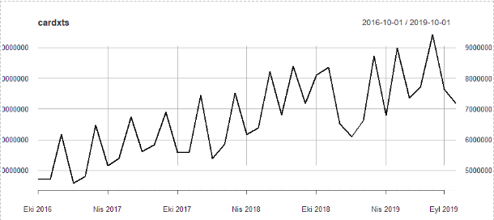

Figure 1: Plot of cardxts

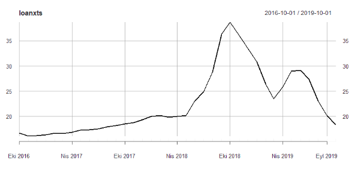

Figure 2: Plot of loanxts

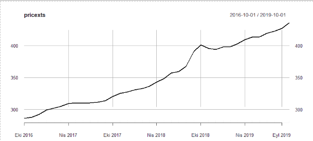

Figure 3: Plot of pricexts

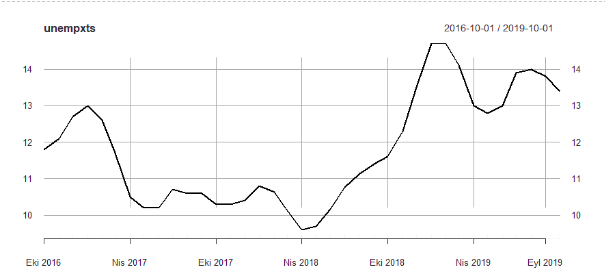

Figure 4: Plot of unempxts

### Comparison of Loanxts and Cardxts

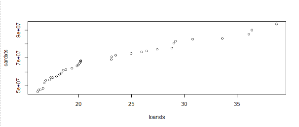

Figure 5: Loanxts against cardxts

### Comparison of Pricexts and Cardxts

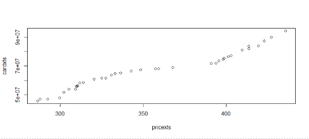

Figure 6: Pricexts against cardxts

### Comparison of Unempxt and Cardxts

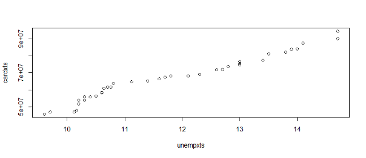

Figure 7: Unempxt against cardxts

## 6.Appendix

### a. Appendix 1: R codes for Tables

cor1 <- cor.test(cardxts, loanxts, method = “pearson”)

cor2 <- cor.test(cardxts, pricexts, method = “pearson”)

cor3 <- cor.test(cardxts, unempxts, method = “pearson”)

### b. Appendix 2: R codes for Plotting Figures

1. Code for **Figure 1**

plot(cardxts)

2. Code for **Figure 2**

plot(loanxts)

3. Code for **Figure 3**

plot(pricexts)

4. Code for **Figure 4**

plot(unempxts)

22. Code for **Figure 5**

qqplot(loanxts,cardxts)

6. Code for **Figure 6**

qqplot(pricexts,cardxts)

7. Code for **Figure 7**

qqplot(unempxts,cardxts)

## 7.CODE

[Here is the github link of the code.](https://github.com/BU-IE-360/ilgazgulsen/blob/master/files/hw1.R)

install.packages(“data.table”) library(data.table) install.packages(“xlsx”) install.packages(“zoo”) install.packages(“xts”) install.packages(“ggpubr”)

library(zoo) library(xts) library(readxl) library(ggpubr)

data <- read_excel(“C:/Users/LENOVO/Desktop/EVDS.xlsx”) View(data) dates<- seq(from=as.Date(“2016-10-01”),to=as.Date(“2019-10-31”),by=“months”) genelxts<-xts(x=data[1:37,],order.by=dates)

card_exp <- data[1:37,2]  
cardxts<- xts(x=card_exp,order.by=dates) #xts object for card usage storage.mode(cardxts) <- “numeric” str(cardxts)

loan_interest<- data[1:37,3]  
loanxts<- xts(x=loan_interest,order.by=dates) #xts object for interest rates of loans storage.mode(loanxts)<- “numeric”

price_index <- data[1:37,4]  
pricexts <- xts(x=price_index,order.by=dates) #xts object for price indexes storage.mode(pricexts)<- “numeric”

unemp_rate <-data[1:37,5] unempxts <- xts(x=unemp_rate,order.by=dates) #xts object for unemployement rates storage.mode(unempxts)<- “numeric”

plot(cardxts) #plot the 4 xts objects plot(loanxts) plot(pricexts) plot(unempxts)

merge(cardxts,loanxts) #compare cardxts wit the other xts object merge(cardxts,pricexts) merge(cardxts,unempxts)

qqplot(loanxts,cardxts) #qqplots of cardxts against other xts objects qqplot(pricexts,cardxts) qqplot(unempxts,cardxts)

cor1 <- cor.test(cardxts, loanxts, method = “pearson”) #correlation measurments between cardxts and other xts objects cor2 <- cor.test(cardxts, pricexts, method = “pearson”) cor3 <- cor.test(cardxts, unempxts, method = “pearson”)

periodicity(cardxts) #periodicity calculations of xts objects (check if they are monthly) periodicity(loanxts) periodicity(pricexts) periodicity(unempxts)